# A quick glance at reported robberies in Mexico City’s transportation system

Rebeca de Buen Kalman

5/8/2020

# Appendix: Exploring reported robberies on Mexico City’s transportation system with R

In this Appendix I will lay out in detail the process I followed for *Exploring reported robberies on Mexico City’s transportation system*. The main data set I use here is the Mexico City [data on street-level crimes](https://datos.cdmx.gob.mx/explore/dataset/carpetas-de-investigacion-pgj-de-la-ciudad-de-mexico/information/?disjunctive.ao_hechos&disjunctive.delito) includes all of the crimes reported to this agency starting in January. This data is updated monthly on the [Mexico City Open Data Portal](https://datos.cdmx.gob.mx/pages/home/).

I also use the shape-files for [Mexico City’s neighborhoods](https://datos.cdmx.gob.mx/explore/dataset/coloniascdmx/export/), [metro lines](https://datos.cdmx.gob.mx/explore/dataset/lineas-de-metro/export/), [metro stations](https://datos.cdmx.gob.mx/explore/dataset/estaciones-metro/export/), [metrobus lines](https://datos.cdmx.gob.mx/explore/dataset/lineas-metrobus/export/) and [metrobus stations](https://datos.cdmx.gob.mx/explore/dataset/estaciones-metrobus/export/).

## R packages

To analyze this data I used the following R packages from the Tidyverse:`readr`, `dplyr`, `forcats`, `ggplot2`, `lubridate` `stringr`, and `sf`.

```r
library(readr) # reading in data
library(dplyr) # data manipulation
library(forcats) # recoding variables
library(ggplot2) # visualization
library(lubridate) # date-time object manipulation
library(stringr) # strings and regular expressions
library(zoo) # moving average functions
library(sf) # working with spatial objects
```

## Research questions

Before jumping into the data, I brainstormed a set of questions to guide this analysis:

- What kinds of crimes are committed on Mexico City’s transportation system (both private cars and public transportation)?
- How do the crimes reported vary by mode?
- Have reported crimes increased or decreased over time? Does this vary by mode?
- What are the months, days of the week and hours when crimes are more frequently committed on different modes of transportation?
- For crimes committed on the Metro and Metrubus what are the most common stations committed?
- For other modes, what neighborhoods are the most dangerous?

## The data

I read in the data and do some initial checks to get familiar with this data set:

```r
#read in data
crimes <- read_csv("../data/carpetas-de-investigacion-pgj-de-la-ciudad-de-mexico_2020-02-22 00_02.csv")
```

To start getting a feel for the data I look at the first few columns of data:

```r
#Visualize first few columns
head(crimes)
```

```
## # A tibble: 6 x 18
##   ao_hechos mes_hechos fecha_hechos        delito categoria_delito fiscalia
##       <dbl> <chr>      <dttm>              <chr>  <chr>            <chr>
## 1      2018 Marzo      2018-03-31 18:30:00 VIOLE~ DELITO DE BAJO ~ INVESTI~
## 2      2018 Marzo      2018-03-31 12:40:00 PERDI~ HECHO NO DELICT~ INVESTI~
## 3      2018 Abril      2018-04-01 00:00:00 NARCO~ DELITO DE BAJO ~ INVESTI~
## 4      2018 Marzo      2018-03-31 23:50:00 CONTR~ DELITO DE BAJO ~ INVESTI~
## 5      2018 Abril      2018-04-01 01:10:00 LESIO~ DELITO DE BAJO ~ INVESTI~
## 6      2018 Febrero    2018-02-07 15:15:00 FALSI~ DELITO DE BAJO ~ INVESTI~
## # ... with 12 more variables: agencia <chr>, unidad_investigacion <chr>,
## #   alcaldia_hechos <chr>, colonia_hechos <chr>, ao_inicio <dbl>,
## #   mes_inicio <chr>, fecha_inicio <dttm>, calle_hechos <chr>,
## #   calle_hechos2 <chr>, longitud <dbl>, latitud <dbl>, geopoint <chr>
```

I check for NAs in each column:

```r
#count NAs i all columns
crimes %>% sapply( function(x) sum(is.na(x)))
```

```
##            ao_hechos           mes_hechos         fecha_hechos
##                  389                  389                  389
##               delito     categoria_delito             fiscalia
##                    0                    0                    0
##              agencia unidad_investigacion      alcaldia_hechos
##                    0                  225                 3086
##       colonia_hechos            ao_inicio           mes_inicio
##                37057                    0                    0
##         fecha_inicio         calle_hechos        calle_hechos2
##                    0                 2505               558332
##             longitud              latitud             geopoint
##                36285                36285                36285
```

The data contains the following columns:

```r
# Get column names
colnames(crimes)
```

```
##  [1] "ao_hechos"            "mes_hechos"           "fecha_hechos"
##  [4] "delito"               "categoria_delito"     "fiscalia"
##  [7] "agencia"              "unidad_investigacion" "alcaldia_hechos"
## [10] "colonia_hechos"       "ao_inicio"            "mes_inicio"
## [13] "fecha_inicio"         "calle_hechos"         "calle_hechos2"
## [16] "longitud"             "latitud"              "geopoint"
```

- **Ao_hechos:** Year of crime. (typo in column name)
- **mes_hechos:** Month of crime.
- **fecha_hechos:** Date of crime.
- **delito:** Crime.
- **categoria_delito:** Crime category.
- **fiscalia:** Prosecution office.
- **agencia:** Agency.
- **unidad_investigacion:** Investigation Unit
- **alcaldia_hechos:** Municipality whee crime was committed.
- **colonia_hechos:** Neighborhood where crime was committed.
- **ao_inicio :** Year when investigation started
- **mes_inicio:** Month when investigation started
- **fecha_inicio:** Date when investigation started .
- **geopoint:** geo-location of crime.
- **colonia_hechos:** Neighborhood where crime was committed.
- **calle_hechos:** Cross-street 1
- **calle_hechos2:** Cross-street 2
- **latitud:** Latitude
- **longitud:** Longitude

This first glance at the data reveals a few issues:

- There is a lot of information that is repetitive (for example date time information, location information).
- There is a lot of data that is unlikely to be used in this analysis.
- I also still some work needs to be done to identify crimes that are committed on different modes of transportation. What types of crimes are included?
- The data needs to be translated into english. I will do this further down the line so that I only translate the variables I need.

# Data cleaning

The objective of this section is to work towards a data set that has the variables I need in the right format to answer my questions.

First, I work to identify the crimes committed on any mode of transportation. For this, I first look at the unique values of the `Delito`(crime) variable for clues using `unique(victimas$Delito)`. This reveals 277 unique categories. Manually sifting through these data I spotted some categories that include the names of different modes. To make sure I capture them all, I look for all the categories that mention modes of transportation.

```r
#list of modes of transportation
modes <- c("METRO", "METROBUS", "TAXI", "PESERO", "TRANSPORTE PÚBLICO", "AUTOBÚS FORÁNEO", "ECOBUS", "RTP", "TROLEBUS", "TREN LIGERO", "TROLEBUS", "VEHICULO", "TREN SUBURBANO", "TAXI")

#regular expression to help identify crimes that include any of te elements in mode
modes_regex <- paste(modes, collapse = "|")

# check if any of the words in modes are inside the delito category names
unique(crimes$delito) %>% str_subset(modes_regex)
```

```
##  [1] "ROBO DE OBJETOS DEL INTERIOR DE UN VEHICULO"
##  [2] "ROBO A PASAJERO / CONDUCTOR DE VEHICULO CON VIOLENCIA"
##  [3] "ROBO DE VEHICULO DE SERVICIO PARTICULAR CON VIOLENCIA"
##  [4] "ROBO DE VEHICULO DE PEDALES"
##  [5] "ROBO A PASAJERO A BORDO DE PESERO COLECTIVO CON VIOLENCIA"
##  [6] "ROBO A NEGOCIO Y VEHICULO CON VIOLENCIA"
##  [7] "ROBO DE VEHICULO DE SERVICIO PARTICULAR SIN VIOLENCIA"
##  [8] "ROBO A PASAJERO A BORDO DE METRO SIN VIOLENCIA"
##  [9] "ROBO A PASAJERO A BORDO DE METRO CON VIOLENCIA"
## [10] "ROBO A PASAJERO A BORDO DE METROBUS SIN VIOLENCIA"
## [11] "ROBO DE VEHICULO DE SERVICIO PÚBLICO SIN VIOLENCIA"
## [12] "TENTATIVA DE ROBO DE VEHICULO"
## [13] "ROBO DE VEHICULO DE SERVICIO PÚBLICO CON VIOLENCIA"
## [14] "ROBO A PASAJERO A BORDO DE TRANSPORTE PÚBLICO CON VIOLENCIA"
## [15] "ROBO A PASAJERO A BORDO DE TRANSPORTE PÚBLICO SIN VIOLENCIA"
```

[output cut: 37 more lines]

This is a good approximation, but I still end up with many categories that don’t reflect the type of crimes that I am looking for, which identifies crimes on people using different modes of transportation. However, a close look at this data reveals that the categories I am interested include the term *passenger* (*PASAJERO*)

```r
unique(crimes$delito) %>% str_subset("PASAJERO")
```

```
##  [1] "ROBO A PASAJERO / CONDUCTOR DE VEHICULO CON VIOLENCIA"
##  [2] "ROBO A PASAJERO A BORDO DE PESERO COLECTIVO CON VIOLENCIA"
##  [3] "ROBO A PASAJERO A BORDO DE METRO SIN VIOLENCIA"
##  [4] "ROBO A PASAJERO A BORDO DE METRO CON VIOLENCIA"
##  [5] "ROBO A PASAJERO A BORDO DE METROBUS SIN VIOLENCIA"
##  [6] "ROBO A PASAJERO A BORDO DE TRANSPORTE PÚBLICO CON VIOLENCIA"
##  [7] "ROBO A PASAJERO A BORDO DE TRANSPORTE PÚBLICO SIN VIOLENCIA"
##  [8] "ROBO A PASAJERO EN TROLEBUS SIN VIOLENCIA"
##  [9] "ROBO A PASAJERO A BORDO DE TAXI CON VIOLENCIA"
## [10] "ROBO A PASAJERO A BORDO DE TAXI SIN VIOLENCIA"
## [11] "ROBO A PASAJERO / CONDUCTOR DE TAXI CON VIOLENCIA"
## [12] "ROBO A PASAJERO EN RTP CON VIOLENCIA"
## [13] "ROBO A PASAJERO EN ECOBUS CON VIOLENCIA"
## [14] "ROBO A PASAJERO A BORDO DE METROBUS CON VIOLENCIA"
## [15] "ROBO A PASAJERO A BORDO DE PESERO COLECTIVO SIN VIOLENCIA"
## [16] "ROBO A PASAJERO EN TREN SUBURBANO CON VIOLENCIA"
## [17] "ROBO A TRANSEUNTE EN TERMINAL DE PASAJEROS CON VIOLENCIA"
## [18] "ROBO A PASAJERO EN RTP SIN VIOLENCIA"
## [19] "ROBO A PASAJERO EN TREN LIGERO SIN VIOLENCIA"
## [20] "ROBO A PASAJERO EN AUTOBÚS FORÁNEO CON VIOLENCIA"
## [21] "ROBO A PASAJERO EN TREN SUBURBANO SIN VIOLENCIA"
## [22] "ROBO A PASAJERO EN ECOBUS SIN VIOLENCIA"
## [23] "ROBO A PASAJERO EN TROLEBUS CON VIOLENCIA"
## [24] "ROBO A PASAJERO A BORDO DE PESERO Y VEHICULO CON VIOLENCIA"
## [25] "ROBO A PASAJERO EN AUTOBUS FORANEO SIN VIOLENCIA"
## [26] "ROBO A PASAJERO EN TREN LIGERO CON VIOLENCIA"
```

With this information, I am ready to subset the data. I notice that the crimes reported by passengers of different modes of transportation are all related to robberies. There is also information on whether the robbery was violent and non-violent.

```r
# filter out crimes that include the word "PASAJERO" but not "TRANSEUNTE"
transport_crimes <- crimes %>% filter(str_detect( delito, "PASAJERO") & !str_detect( delito, "TRANSEUNTE"))

head(transport_crimes)
```

```
## # A tibble: 6 x 18
##   ao_hechos mes_hechos fecha_hechos        delito categoria_delito fiscalia
##       <dbl> <chr>      <dttm>              <chr>  <chr>            <chr>
## 1      2018 Abril      2018-04-01 05:10:00 ROBO ~ DELITO DE BAJO ~ INVESTI~
## 2      2018 Marzo      2018-03-31 10:40:00 ROBO ~ ROBO A PASAJERO~ INVESTI~
## 3      2014 Abril      2014-04-02 07:00:00 ROBO ~ ROBO A PASAJERO~ INVESTI~
## 4      2018 Marzo      2018-03-26 19:10:00 ROBO ~ ROBO A PASAJERO~ INVESTI~
## 5      2018 Abril      2018-04-02 01:30:00 ROBO ~ DELITO DE BAJO ~ INVESTI~
## 6      2018 Marzo      2018-03-24 10:30:00 ROBO ~ ROBO A PASAJERO~ INVESTI~
## # ... with 12 more variables: agencia <chr>, unidad_investigacion <chr>,
## #   alcaldia_hechos <chr>, colonia_hechos <chr>, ao_inicio <dbl>,
## #   mes_inicio <chr>, fecha_inicio <dttm>, calle_hechos <chr>,
## #   calle_hechos2 <chr>, longitud <dbl>, latitud <dbl>, geopoint <chr>
```

```r
#select desired variables and translate variable names
transport_crimes <- transport_crimes %>% select(crime = delito,
                                                      datetime = fecha_hechos,
                                                      lat = latitud,
                                                      lon = longitud,
                                                      municipality = alcaldia_hechos,
                                                      neighborhood = colonia_hechos)
```

The `crime` variable contains two important pieces of information that still needs to be separated. The category includes - the mode of transportation where victims were robbed - whether the robbery was violent. To sparate this informetion I create two additional categorical variables. `transp_mode` to indicate the mode, and `violence`, which indicates whether or not the robbery was violent. With this information parsed out, I can also remove the `crime` variable from my data set.

```r
transport_crimes <- transport_crimes %>%
                      #create categorical transp_mode variable.
                        mutate( transp_mode = factor(case_when(
                            is.na(crime) ~ NA_character_,
                            str_detect(crime, "METROBUS") ~ "METROBUS",
                            str_detect(crime, "METRO") ~ "METRO",
                            str_detect(crime, "PESERO") ~ "PESERO",
                            str_detect(crime, "TRANSPORTE PÚBLICO") ~ "TRANSPORTE PUBLICO",
                            str_detect(crime, "AUTOBÚS FORÁNEO") ~ "AUTOBUS FORANEO",
                            str_detect(crime, "AUTOBUS FORANEO") ~ "AUTOBUS FORANEO",
                            str_detect(crime, "ECOBUS") ~ "ECOBUS",
                            str_detect(crime, "RTP") ~ "RTP",
                            str_detect(crime, "TREN LIGERO") ~ "TREN LIGERO",
                            str_detect(crime, "TROLEBUS") ~ "TROLEBUS",
                            str_detect(crime, "VEHICULO") ~ "VEHICULO",
                            str_detect(crime, "TREN SUBURBANO") ~ "TREN SUBURBANO",
                            str_detect(crime, "TAXI") ~ "TAXI"
                          ))) %>%
                    # create categorical variable for violence
                      mutate( violence = factor(case_when(
                        is.na(crime) ~ NA_character_,
                        str_detect(crime, "CON VIOLENCIA") ~ "Yes",
                        str_detect(crime, "SIN VIOLENCIA") ~ "No"
                      ))) %>%

                    # remove crime column from the data
                    select(-crime)
```

I check how many data points are in each `transp_mode` category to see if I should create a an `OTHER` category. I also note that there is a category called `TRANSPORTE PUBLICO` where I don’t know the specific mode.

```r
 transport_crimes %>% count()
```

```
## # A tibble: 1 x 1
##       n
##   <int>
## 1 36001
```

```r
 transport_crimes %>% group_by(transp_mode) %>% count()
```

```
## # A tibble: 12 x 2
## # Groups:   transp_mode [12]
##    transp_mode            n
##    <fct>              <int>
##  1 AUTOBUS FORANEO       60
##  2 ECOBUS                45
##  3 METRO              10037
##  4 METROBUS            2867
##  5 PESERO              3467
##  6 RTP                  124
##  7 TAXI                2819
##  8 TRANSPORTE PUBLICO  5752
##  9 TREN LIGERO           89
## 10 TREN SUBURBANO        22
## 11 TROLEBUS             177
## 12 VEHICULO           10542
```

```r
transport_crimes <- transport_crimes %>% mutate(transp_mode = fct_recode(transp_mode, Metro = "METRO",
                                                                    Car = "VEHICULO",
                                                                    Pesero =  "PESERO",
                                                                    Other = "TRANSPORTE PUBLICO",
                                                                    Taxi =  "TAXI",
                                                                    Other = "RTP",
                                                                    Metrobus  = "METROBUS",
                                                                    Other = "TREN LIGERO",
                                                                    Other = "TROLEBUS",
                                                                    Other = "AUTOBUS FORANEO",
                                                                    Other = "TREN SUBURBANO",
                                                                    Other = "ECOBUS"))

# smell test for recode
 transport_crimes %>% group_by(transp_mode) %>% count()
```

```
## # A tibble: 6 x 2
## # Groups:   transp_mode [6]
##   transp_mode     n
##   <fct>       <int>
## 1 Other        6269
## 2 Metro       10037
## 3 Metrobus     2867
## 4 Pesero       3467
## 5 Taxi         2819
## 6 Car         10542
```

I check for NAs in each column.

```r
sapply(transport_crimes, function(x) sum(is.na(x)))
```

```
##     datetime          lat          lon municipality neighborhood  transp_mode
##            8          483          483          114          506            0
##     violence
##            0
```

I check on how the data is distributed over time

```r
# group by years and count to check distribution of data over time
transport_crimes %>% select(transp_mode, datetime) %>%
                      mutate(year = year(datetime)) %>%
                      group_by(year) %>% count()
```

```
## # A tibble: 22 x 2
## # Groups:   year [22]
##     year     n
##    <dbl> <int>
##  1  1915     1
##  2  1955     1
##  3  1958     1
##  4  1969     1
##  5  1980     1
##  6  1986     2
##  7  1990     1
##  8  1993     1
##  9  2001     3
## 10  2007     1
## # ... with 12 more rows
```

For practical purposes, I will focus on the the data for 2016-2019. These years contain a larger amount of reports and are the most recent years with a full year’s worth of data.

```r
# Take transport crimes
transport_crimes <- transport_crimes %>%
                      mutate(week = week(datetime), year = year(datetime)) %>%
                      filter (year > 2015) %>% filter(!is.na(transp_mode))
```

I add a few mre variables that I will need further down

```r
transport_crimes <- transport_crimes %>% mutate(
                                               year = as.factor(year(datetime)),
                                                month = as.factor(month(datetime)),
                                                day = date(datetime),
                                                weekday = as.factor(wday(datetime)),
                                                hour = as.factor(hour(datetime))
                                                )
```

Finally, I look at the data set to see what I ended up with.

```r
head(transport_crimes)
```

```
## # A tibble: 6 x 13
##   datetime              lat   lon municipality neighborhood transp_mode violence
##   <dttm>              <dbl> <dbl> <chr>        <chr>        <fct>       <fct>
## 1 2018-04-01 05:10:00  19.4 -99.2 ALVARO OBRE~ LOMAS DE BE~ Car         Yes
## 2 2018-03-31 10:40:00  19.3 -99.1 IZTAPALAPA   LOS REYES C~ Pesero      Yes
## 3 2018-03-26 19:10:00  19.4 -99.1 VENUSTIANO ~ ROMERO RUBIO Metro       No
## 4 2018-04-02 01:30:00  19.4 -99.1 IZTACALCO    MILITAR MAR~ Car         Yes
## 5 2018-03-24 10:30:00  19.4 -99.1 CUAUHTEMOC   CENTRO       Metro       Yes
## 6 2018-03-27 19:30:00  19.4 -99.2 BENITO JUAR~ NAPOLES      Metrobus    No
## # ... with 6 more variables: week <dbl>, year <fct>, month <fct>, day <date>,
## #   weekday <fct>, hour <fct>
```

I am now in better shape to answer my research questions. In the following sections, As I explore the data, I continue to manipulate it as needed.

## Analysis and visualization

*What kinds of crimes are committed on Mexico City’s transportation system (both private cars and public transportation)?How do the crimes reported vary by mode?*

The crimes included in the data set for modes of transportation are violent and non-violent robberies. I explore how these are distributed across modes for the entire time period (2016-2019).

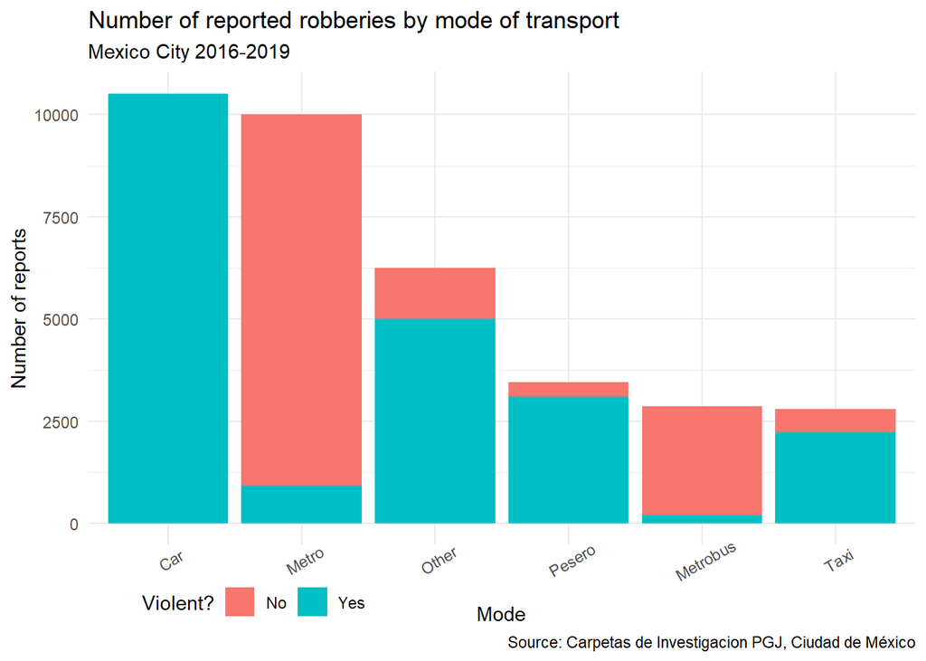

```r
# I group by mode and count so that my categorical variable is ordered by the frequency of crimes
mode_levels <- transport_crimes %>% group_by(transp_mode) %>% count() %>% arrange(n) %>% pull(transp_mode)

# I make a simple frequency plot to vizualize how many crimes are reported for each mode. I separate these by violent and non-violent crime.
transport_crimes %>% select(transp_mode, violence) %>%
                      #order frequency plot modes from highest to lowest counts
                      mutate(transp_mode = factor(transp_mode, levels=rev(mode_levels))) %>%
                      ggplot(aes(x=transp_mode, fill = violence)) +
                      geom_bar() +
                      # fix labels and legend
                      labs(
                      title = "Number of reported robberies by mode of transport",
                      subtitle = "Mexico City 2016-2019",
                      caption = "Source: Carpetas de Investigacion PGJ, Ciudad de México") +
                      xlab("Mode") +
                      ylab("Number of reports") +
                      scale_fill_discrete(name = "Violent?") +
                      theme_minimal() +
                      theme(legend.position= c(0.2,-0.12), legend.direction="horizontal") +
                      theme(axis.text.x = element_text(angle = 30))
```

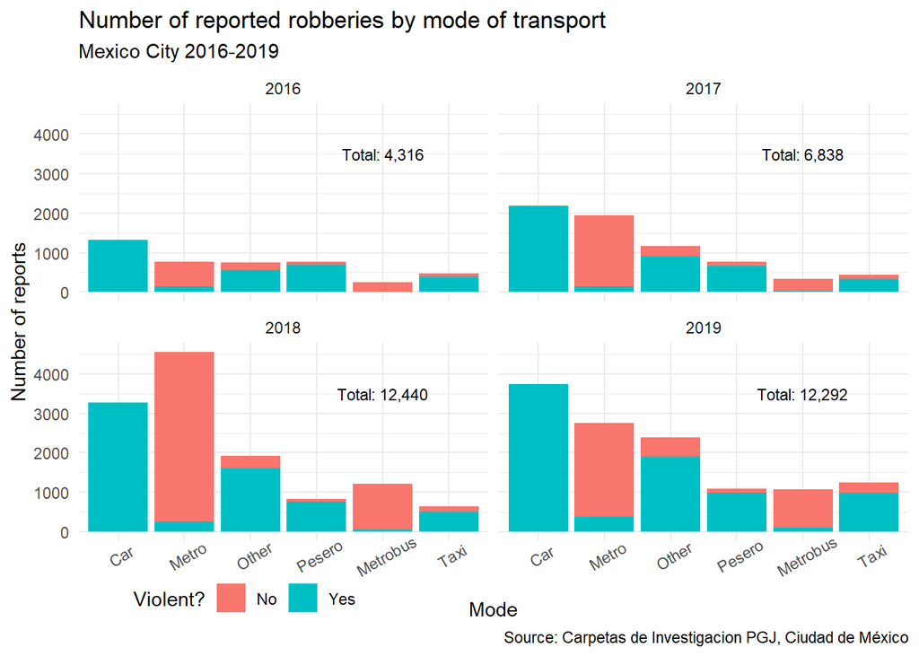

```r
#totals <- transport_crimes %>% group_by(year) %>% count()

year <- c(2016, 2017, 2018, 2019)
x_coords <- c(5, 5, 5, 5)
y_coords <- c(3500, 3500, 3500, 3500)
text <- c("Total: 4,316",
          "Total: 6,838",
          "Total: 12,440",
          "Total: 12,292")

year_totals <- data.frame(year, x_coords, y_coords, text)

transport_crimes %>% select(transp_mode, violence, year) %>%
                      #order frequency plot modes from highest to lowest counts
                      mutate(transp_mode = factor(transp_mode, levels=rev(mode_levels))) %>%
                      ggplot(aes(x=transp_mode, fill = violence)) +
                      geom_bar() +
                      geom_text(data = year_totals,
                                mapping = aes(x = x_coords, y = y_coords, label = text),
                                inherit.aes = FALSE, size = 3) +
                      facet_wrap(~year) +
                      # fix labels and legend
                      labs(
                      title = "Number of reported robberies by mode of transport",
                      subtitle = "Mexico City 2016-2019",
                      caption = "Source: Carpetas de Investigacion PGJ, Ciudad de México") +
                      xlab("Mode") +
                      ylab("Number of reports") +
                      scale_fill_discrete(name = "Violent?") +
                      theme_minimal() +
                      theme(legend.position= c(0.2,-0.13), legend.direction="horizontal") +
                      theme(axis.text.x = element_text(angle = 30))
```

- Have reported crimes increased or decreased over time? Does this vary by mode?*

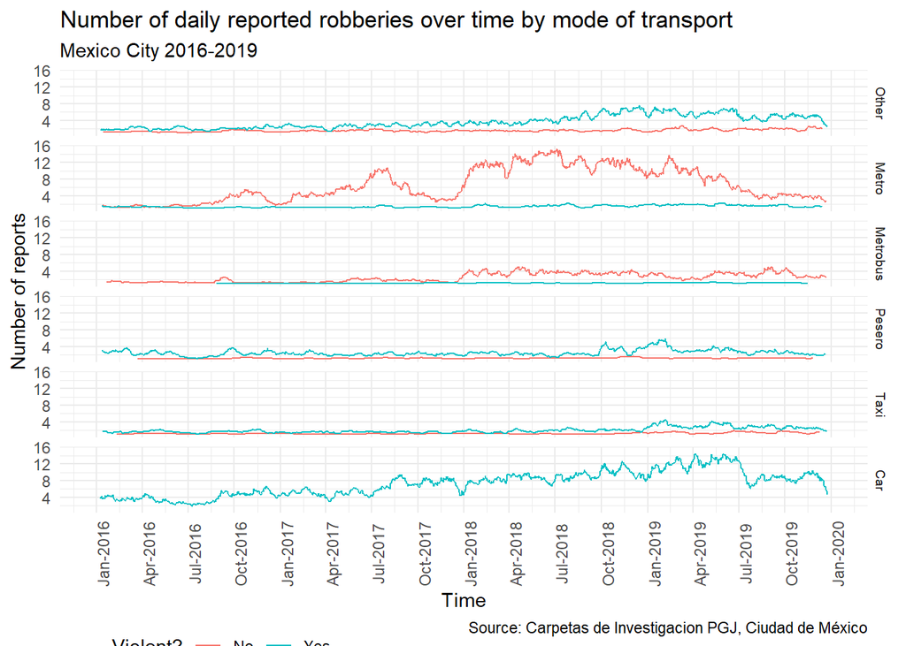

```r
transport_crimes %>%
  select(transp_mode, violence, day) %>%
  group_by(day, violence, transp_mode) %>% count() %>% ungroup() %>%
  group_by(transp_mode, violence) %>%
  arrange(day) %>% # Make sure days are in order for rolling mean
  mutate(avg_n_7 = rollmean(n, 14, fill = c(NA, "extend", NA)))  %>% # 14 day rolling mean
                    ggplot(aes(x = day, y = avg_n_7, color = violence, group = violence)) + geom_line() +
                    facet_grid(transp_mode ~ .) +
                    scale_x_date(date_breaks = "3 months", date_labels = "%b-%Y") +
                    theme_minimal() +
                    ylab("Number of reports") + xlab("Time") +
                    theme_minimal() +
                    theme(axis.text.x = element_text(angle = 90)) +
                      labs(
                      title = "Number of daily reported robberies over time by mode of transport",
                      subtitle = "Mexico City 2016-2019",
                      caption = "Source: Carpetas de Investigacion PGJ, Ciudad de México") +
                      theme(legend.position= c(0.2,-0.3), legend.direction="horizontal") +
                      scale_color_discrete(name = "Violent?") +
                      theme(strip.text = element_text(size = 7))
```

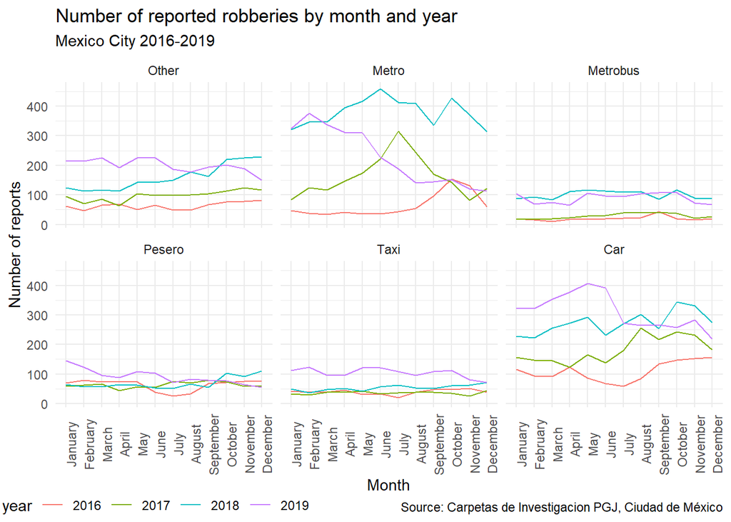

```r
 transport_crimes %>% select(violence, year, month, transp_mode) %>%
                    group_by(year, month, transp_mode) %>%
                    count(month) %>%
                    ggplot(aes(x= month, y = n, group = year, color = year))  + geom_line() +                                    facet_wrap(~transp_mode) +
                    theme_minimal() +
                    labs(title = "Number of reported robberies by month and year",
                      subtitle = "Mexico City 2016-2019",
                      caption = "Source: Carpetas de Investigacion PGJ, Ciudad de México") +
                      xlab("Month") +
                      ylab("Number of reports") +
                    scale_x_discrete(labels=c("1" = "January",
                                              "2" = "February",
                                              "3" = "March",
                                              "4" = "April",
                                              "5" = "May",
                                              "6" = "June",
                                              "7" = "July",
                                              "8" = "August",
                                              "9" = "September" ,
                                              "10" = "October",
                                              "11" = "November",
                                              "12" = "December"))  +
                    theme(axis.text.x = element_text(angle = 90)) +
                    theme(legend.position= c(0.15,-0.3), legend.direction="horizontal")
```

*What are the months, days of the week and hours when crimes are more frequently committed on different modes of transportation?*

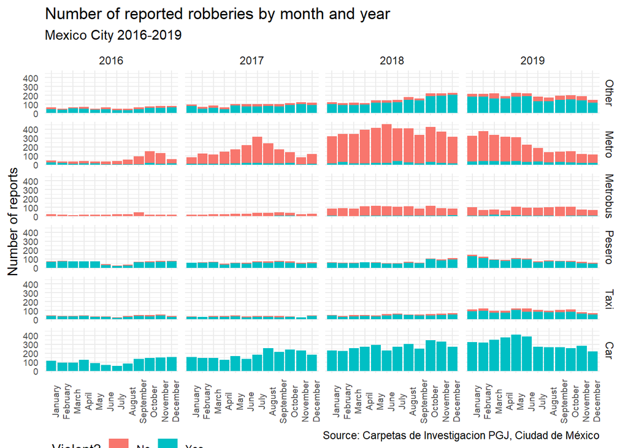

```r
transport_crimes %>% select(violence, month, transp_mode, year) %>%
                    group_by(violence, month, transp_mode, year) %>%
                    ggplot(aes(x= month, group = violence, fill = violence))  +
                    geom_bar() +
                    facet_grid(transp_mode ~ year) +
                    labs(title = "Number of reported robberies by month and year",
                      subtitle = "Mexico City 2016-2019",
                      caption = "Source: Carpetas de Investigacion PGJ, Ciudad de México") +
                      ylab("Number of reports") +
                    scale_x_discrete(labels=c("1" = "January", "2" = "February", "3" = "March",
                                              "4" = "April", "5" = "May", "6" = "June", "7" = "July",
                                              "8" = "August",  "9" = "September" , "10" = "October", "11" =
                                                "November", "12" = "December"))  +
                    theme_minimal() +
                    theme(axis.text.x = element_text(angle = 90)) +
                    theme(legend.position= c(0.15,-0.25), legend.direction="horizontal") +
                    scale_fill_discrete(name = "Violent?") + theme(axis.text=element_text(size=7)) +
                    theme(axis.title.x = element_blank())
```

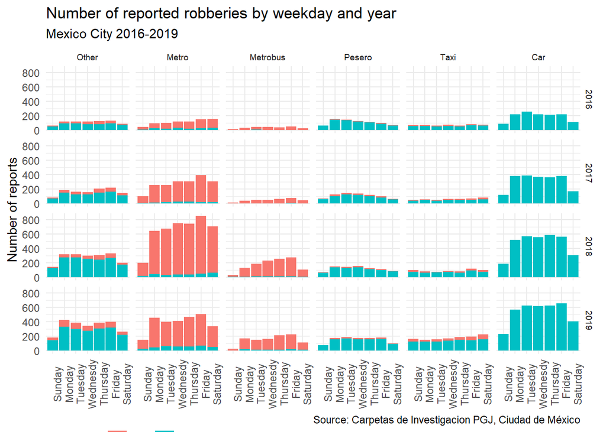

```r
transport_crimes %>% select(transp_mode, violence, weekday, year) %>%
                    group_by(violence, weekday, transp_mode) %>%
                    ggplot(aes(x= weekday, group = violence, fill = violence))  +
                    geom_bar() +
                    facet_grid(year~transp_mode) +
                    theme_minimal() +
                    scale_x_discrete(labels=c("1" = "Sunday", "2" = "Monday", "3" = "Tuesday",
                                              "4" = "Wednesdy", "5" = "Thursday", "6" = "Friday", "7" = "Saturday")) +
                    theme(axis.text.x = element_text(angle = 90)) +
                    theme(legend.position= c(0.15,-0.24), legend.direction="horizontal") +
                    scale_fill_discrete(name = "Violent?") +
                      labs(title = "Number of reported robberies by weekday and year",
                      subtitle = "Mexico City 2016-2019",
                      caption = "Source: Carpetas de Investigacion PGJ, Ciudad de México") +
                      ylab("Number of reports") +
                    theme(axis.text.x = element_text(angle = 90)) + theme(legend.position= c(0.15,-0.3), legend.direction="horizontal") +
                    scale_fill_discrete(name = "Violent?") +
                    theme(axis.title.x = element_blank()) +
                    theme(strip.text = element_text(size = 7))
```

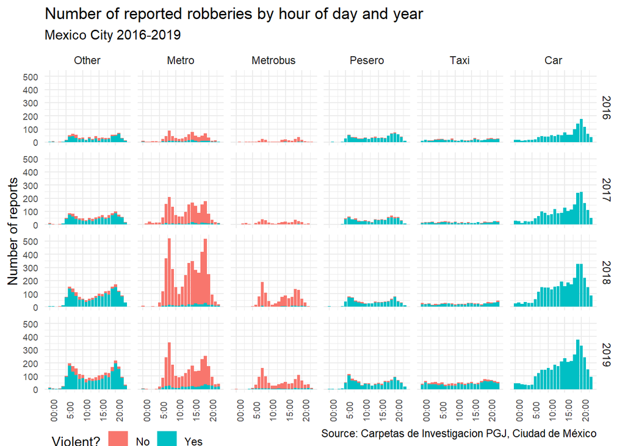

```r
 transport_crimes %>%  select(transp_mode, datetime, violence) %>%
                      mutate(hour = hour(datetime), year = year(datetime)) %>%
                     ggplot(aes(x = hour, fill = violence)) + geom_bar() +
                    facet_grid(year~transp_mode) +
                    theme_minimal() +
                    theme(strip.text.x = element_text(size = rel(0.6))) +
                    ylab("Number of crimes") +
                    theme(axis.title.x = element_blank()) +
                    theme_minimal() +
                      labs(title = "Number of reported robberies by hour of day and year",
                      subtitle = "Mexico City 2016-2019",
                      caption = "Source: Carpetas de Investigacion PGJ, Ciudad de México") +
                      ylab("Number of reports") +
                      scale_x_continuous(breaks = c(0,5,10,15,20), labels= c(`0` = "00:00", `5` = "5:00",
                                                                             `10` = "10:00", `15`= "15:00", `20` = "20:00")) +
                    theme(axis.text.x = element_text(angle = 90)) +
                    theme(axis.title.x = element_blank()) + theme(axis.text=element_text(size=7)) +
                    theme(legend.position= c(0.15,-0.15), legend.direction="horizontal") +
                    scale_fill_discrete(name = "Violent?")
```

To explore questions related to locations, I will use the additional data sets that include shapefiles for Mexico City Neighborhoods, Transit (Metro and Metrobus) Lines, and Transit Stations.

```r
# Load neighborhood ("colonias") shapefiles
colonias <- st_read("../data/coloniascdmx.shp") %>% select(name = nombre, geometry) %>% st_transform(4485)
```

```
## replacing null geometries with empty geometries
## Simple feature collection with 1812 features and 7 fields (with 4 geometries empty)
## geometry type:  GEOMETRY
## dimension:      XY
## bbox:           xmin: -99.35038 ymin: 19.12798 xmax: -98.94565 ymax: 19.59378
## geographic CRS: WGS 84
```

```r
# glance at the data
head(colonias)
```

```
## Simple feature collection with 6 features and 1 field
## geometry type:  POLYGON
## dimension:      XY
## bbox:           xmin: 1742411 ymin: 2177527 xmax: 1752575 ymax: 2192076
## projected CRS:  Mexico ITRF92 / UTM zone 12N
##                                      name                       geometry
## 1                    LOMAS DE CHAPULTEPEC POLYGON ((1743493 2191136, ...
## 2 LOMAS DE REFORMA (LOMAS DE CHAPULTEPEC) POLYGON ((1742588 2189493, ...
## 3                    DEL BOSQUE (POLANCO) POLYGON ((1744732 2191762, ...
## 4              PEDREGAL DE SANTA URSULA I POLYGON ((1752272 2179507, ...
## 5                                AJUSCO I POLYGON ((1750836 2180604, ...
## 6               VISTAS DEL MAUREL (U HAB) POLYGON ((1749303 2177713, ...
```

```r
# make lat and lon into gemetrical object sf can work with
transport_crimes_geolocated <- transport_crimes %>% filter(!is.na(lat)) %>% st_as_sf(coords = c("lon", "lat"), crs=4326) %>% st_transform(4485)
```

```r
metro_lines <- st_read("../data/lineas-de-metro/lineas-de-metro.shp") %>% st_transform(4485) %>%
                    mutate(line = fct_recode(name, "Line 1" = "Línea 1",
                                               "Line 2" = "Línea 2",
                                               "Line 3" = "Línea 3",
                                               "Line 4" = "Línea 4",
                                               "Line 5" = "Línea 5",
                                               "Line 6" = "Línea 6",
                                               "Line 7" = "Línea 7",
                                               "Line 8" = "Línea 8",
                                               "Line 9" = "Línea 9",
                                               "Line A" = "Línea A",
                                               "Line B" = "Línea B",
                                               "Line 12" = "Línea 12")) %>%
                                              select(-name)
metro_stations <- st_read("../data/estaciones-metro/estaciones-metro.shp") %>% st_transform(4485) %>% st_buffer(dist = units::as_units(250, "m"))
```

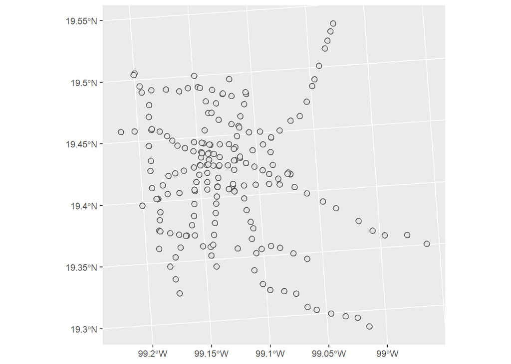

```r
ggplot(metro_stations) + geom_sf()
```

First, I plot the points where crimes are reported over the metro lines

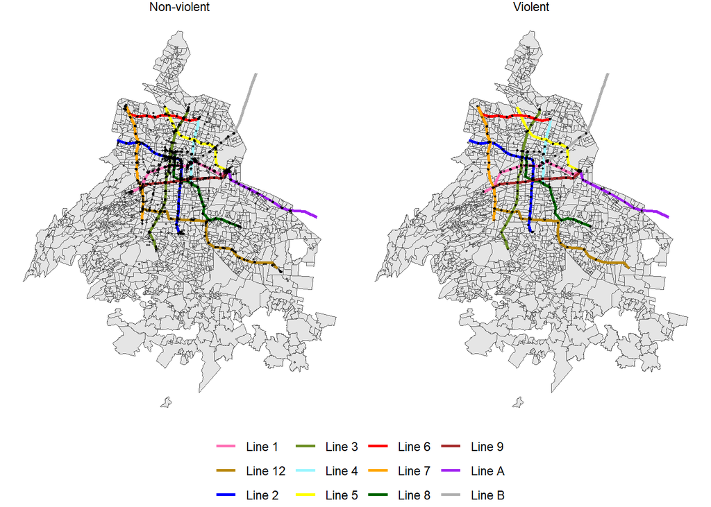

```r
metro_crimes <- transport_crimes_geolocated %>% filter(transp_mode == "Metro")


cols <- c("Line 1" = "hotpink1", "Line 2" = "blue", "Line 3" = "olivedrab",
          "Line 4" = "cadetblue1", "Line 5" = "yellow", "Line 6" = "red",
          "Line 7" = "orange", "Line 8" = "darkgreen", "Line 9" = "brown",
          "Line A" = "purple", "Line B" = "grey69", "Line 12" = "darkgoldenrod")

violence.labs <- c(Yes = "Violent", No = "Non-violent")


ggplot(colonias) +
  geom_sf(size = 0.1) +
  geom_sf(data = metro_lines, aes(color = line), size = 1) + scale_colour_manual(values = cols) +
  geom_sf(data=metro_crimes,  color = "black", size = 0.4, alpha = 0.5) +
    facet_wrap(~violence, labeller = labeller(violence = violence.labs)) +
    theme_void() + theme(legend.title = element_blank()) +
  theme(legend.position= "bottom", legend.direction="horizontal")
```

```r
colonias_crimes <- colonias %>% st_join(metro_crimes) %>% filter()

colonias_counts <- colonias_crimes %>%
  filter(!is.na(name)) %>%
  st_drop_geometry() %>%
  group_by(name) %>%
  summarize(n = n()) %>%
  full_join(colonias %>%
              filter(!is.na(name)) %>%
              group_by(name) %>%
              slice(1L) %>%
              select(name, geometry)) %>%
  mutate(n = ifelse(is.na(n), 0, n)) %>%
  st_as_sf()
```

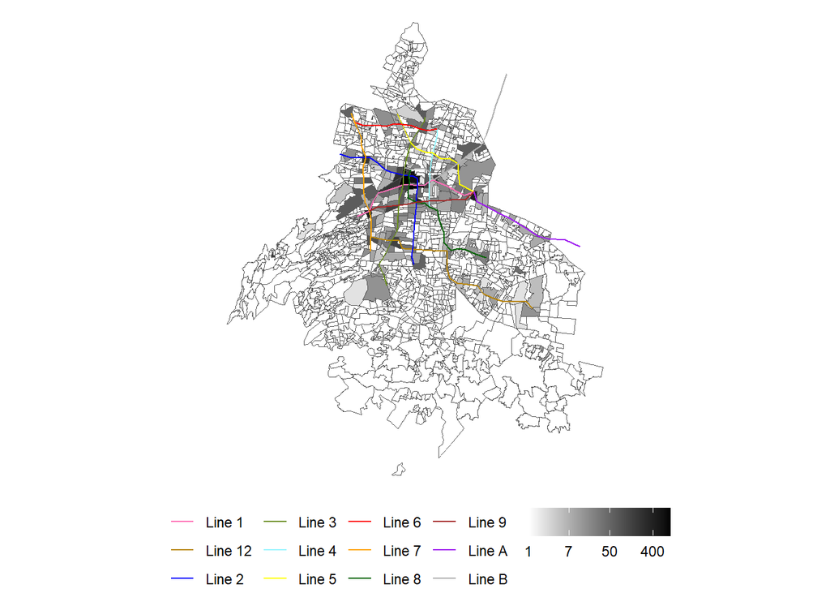

```r
colonias_counts %>% ggplot(aes(fill = n)) +
  geom_sf(size = 0.1) +
  scale_fill_gradient(low = "white", high = "black",
                      na.value = NA, trans = "log", breaks = c(1, 7, 50, 400)) + theme_void() +
    geom_sf(data = metro_lines, aes(color = line), size = 0.5, inherit.aes = FALSE) +
  scale_colour_manual(values = cols) +
     theme(legend.title = element_blank()) +
  theme(legend.position= "bottom", legend.direction="horizontal")
```

```r
station_crimes <- metro_crimes %>% st_join(metro_stations)
station_counts <- station_crimes %>%
  st_drop_geometry() %>%
  group_by(violence, stop_name) %>%
  summarize(n = n()) %>% arrange(desc(n, by_group = TRUE)) %>%
  mutate(stop_name = str_remove_all(stop_name, "[_1234567890]")) %>%
  ungroup()

top_violent_stations <- station_counts %>% select(stop_name, violence, n) %>%
  filter(!is.na(stop_name), violence == "Yes") %>%
  group_by(stop_name) %>% slice(1)  %>%
  arrange(desc(n, by_group = TRUE)) %>%
  ungroup() %>%
  select(-violence) %>%
  top_n(10)

top_nonviolent_stations <- station_counts %>% select(stop_name, violence, n) %>%
  filter(!is.na(stop_name), violence == "No") %>%
  group_by(stop_name) %>%
  slice(1)  %>%
  arrange(desc(n, by_group = TRUE)) %>%
  select(-violence) %>%
  top_n(10)
```

**Neighborhoods**

[output not shown]

```r
mode_crimes <- function(mode){
mode_crimes <- transport_crimes_geolocated %>% filter(transp_mode == mode)
colonias_crimes <- colonias %>% st_join(mode_crimes)
colonias_counts <- colonias_crimes %>%
  filter(!is.na(name)) %>%
  st_drop_geometry() %>%
  group_by(name) %>%
  summarize(n = n()) %>%
  full_join(colonias %>%
              filter(!is.na(name)) %>%
              group_by(name) %>%
              slice(1L) %>%
              select(name, geometry)) %>%
  mutate(n = ifelse(is.na(n), 0, n)) %>%
  st_as_sf()

colonias_counts %>% ggplot(aes(fill = n)) +
  geom_sf(size = 0.1) +
  scale_fill_gradient(low = "yellow", high = "red", na.value = NA, trans = "log", breaks = c(1, 30, 100))  +
  theme_void() +
   theme(legend.title = element_blank()) +
  labs(title = paste0("Number of reported robberies by ", mode, " users"),
                      subtitle = "Mexico City 2016-2019",
                      caption = "Source: Carpetas de Investigacion PGJ, Ciudad de México")
}
```

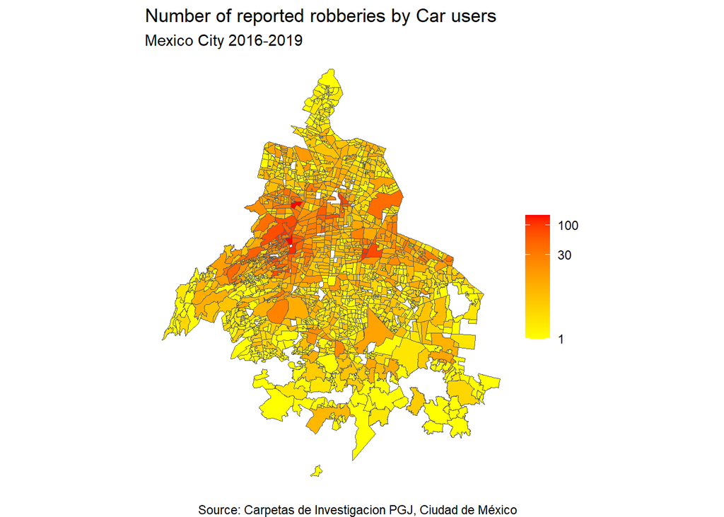

```r
mode_crimes("Car")
```

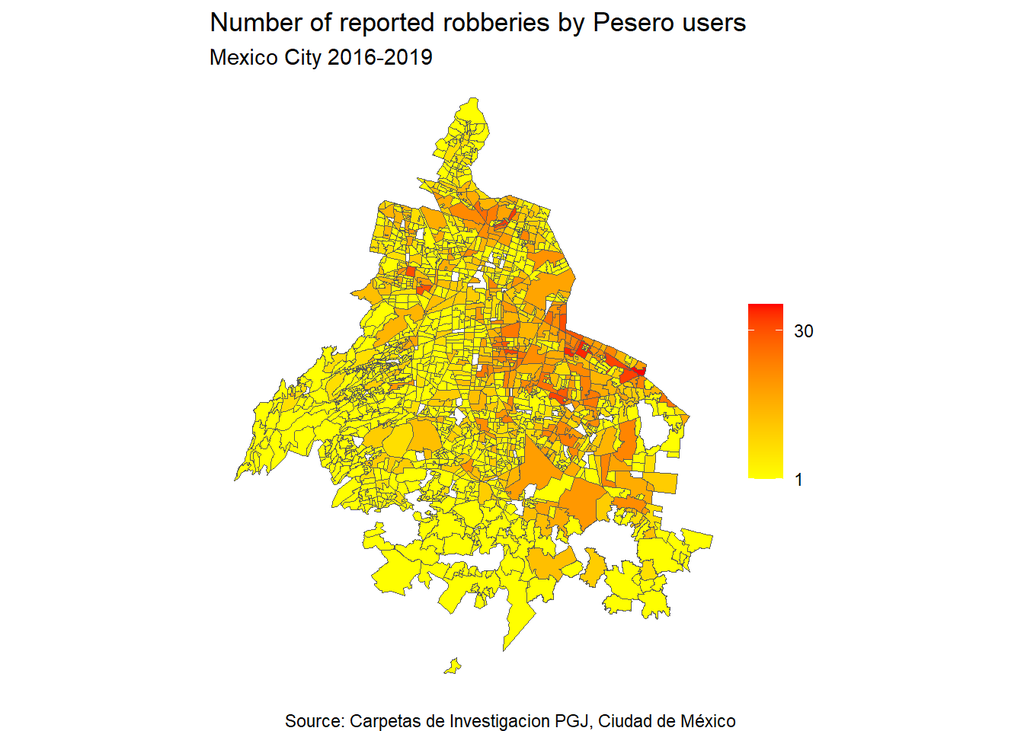

```r
mode_crimes("Pesero")
```

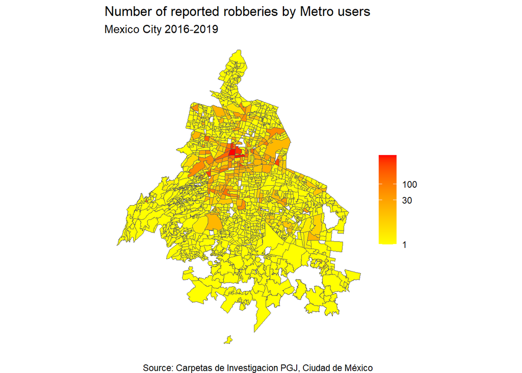

```r
mode_crimes("Metro")
```

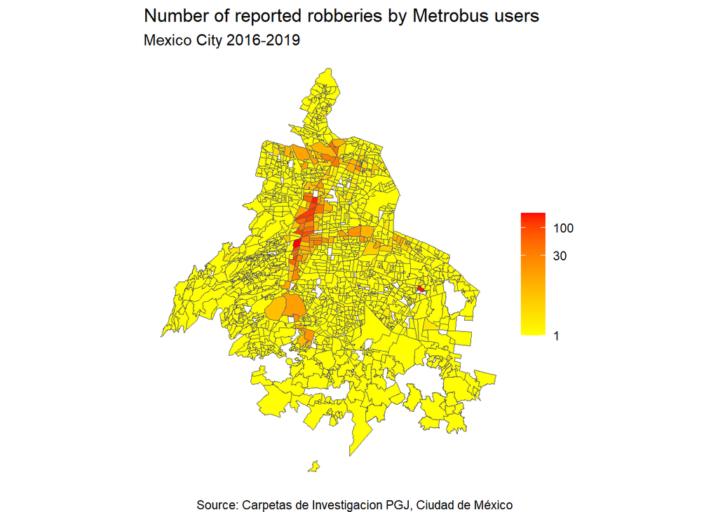

```r
mode_crimes("Metrobus")
```